# Hw4 markdown

SamG

April 21, 2019

Last year for each order placed, which carrier cost the cheapest and how much did that cost?

```r
hist_orders <- read_csv("historical.orders.csv")
hist_trans <- read_csv("historical.transportation.csv")
transportation_costs <- hist_trans %>%
  mutate(cost.with.X = ifelse(hist_trans$`Str Nbr` == "1" & hist_trans$Supplier == "A",
                              2540,
                              ifelse(hist_trans$`Str Nbr` == "2" & hist_trans$Supplier == "A",
                                     1640,
                                     ifelse(hist_trans$Supplier == "B",
                                            1200,
                                            0)))) %>%
  mutate(cost.with.y = ifelse(hist_trans$`Str Nbr` == "1" & hist_trans$Supplier == "A",
                              Weight*.12,
                              ifelse(hist_trans$`Str Nbr` == "2" & hist_trans$Supplier == "B",
                                     Weight*.04,
                                     Weight*.07))) %>%
  mutate(cheaper = ifelse(cost.with.y < cost.with.X,
                          cost.with.y,
                          cost.with.X)) #this adds a column for the cheapest option

head <- transportation_costs %>%
  head(10)
head1 <- as.table(as.matrix(head))
```

```r
kable(head1,row.names = FALSE)
```

| Shipment Date | Str Nbr | Supplier | Weight | cost.with.X | cost.with.y | cheaper |
| --- | --- | --- | --- | --- | --- | --- |
| 8/4/2014 | 1 | A | 15551 | 2540 | 1866.12 | 1866.12 |
| 8/4/2014 | 1 | B | 15687 | 1200 | 1098.09 | 1098.09 |
| 8/4/2014 | 2 | A | 14128 | 1640 | 988.96 | 988.96 |
| 8/4/2014 | 2 | B | 21049 | 1200 | 841.96 | 841.96 |
| 8/11/2014 | 1 | A | 16671 | 2540 | 2000.52 | 2000.52 |
| 8/11/2014 | 1 | B | 14425 | 1200 | 1009.75 | 1009.75 |
| 8/11/2014 | 2 | A | 13172 | 1640 | 922.04 | 922.04 |
| 8/11/2014 | 2 | B | 16733 | 1200 | 669.32 | 669.32 |
| 8/18/2014 | 1 | A | 15800 | 2540 | 1896.00 | 1896.00 |
| 8/18/2014 | 1 | B | 14791 | 1200 | 1035.37 | 1035.37 |

For next year, orders will grow 10% in quantity, so the weight of those orders will also grow.

```r
projected.orders <- hist_orders %>%
  mutate(next.yr.orders = `Order Qty`* 1.1,
         next.yr.weight = next.yr.orders * `Product Weight`)
```

Next year, the company is anticipating roughly the same number of hammers to be ordered as wrenches. Supplier A makes them for $.80 and supplier B makes them for $.82. It is then going to cost $361385 to produce all hammers for next year from supplier A and $370420 to produce all hammers from supplier B

```r
projected.orders %>%
  filter(`Product Id` == "1") %>%
  summarize(hammer.costA = sum(next.yr.orders)*.80,
            hammer.costB = sum(next.yr.orders)*.82,
            hammer.costA.perwk = hammer.costA / 52,
            hammer.costB.perwk = hammer.costB /52)
```

```
## # A tibble: 1 x 4
##   hammer.costA hammer.costB hammer.costA.perwk hammer.costB.perwk
##          <dbl>        <dbl>              <dbl>              <dbl>
## 1      361385.      370420.              6950.              7123.
```

These hammers weigh 2 pounds, so the total weight of hammers shipped next year will be 903463 lbs, or 17374 lbs per week.

```r
projected.orders %>%
  filter(`Product Id` == "1") %>%
  mutate(order.hammer.weight = next.yr.orders * 2) %>% #this is how much each order will weigh
  summarize(total.hammer.weight = sum(order.hammer.weight),
            amt.shipped.per.week = total.hammer.weight/52)
```

```
## # A tibble: 1 x 2
##   total.hammer.weight amt.shipped.per.week
##                 <dbl>                <dbl>
## 1             903463.               17374.
```

With the new hammer orders, transportation costs will increase.

```r
projected_transportation <- transportation_costs %>%
  mutate(new_weight = Weight + (17374/4)) %>%
  mutate(newcost.with.X = ifelse(hist_trans$`Str Nbr` == "1" & hist_trans$Supplier == "A",
                              2540,
                              ifelse(hist_trans$`Str Nbr` == "2" & hist_trans$Supplier == "A",
                                     1640,
                                     ifelse(hist_trans$Supplier == "B",
                                            1200,
                                            0)))) %>%
  mutate(newcost.with.y = ifelse(hist_trans$`Str Nbr` == "1" & hist_trans$Supplier == "A",
                              new_weight*.12,
                              ifelse(hist_trans$`Str Nbr` == "2" & hist_trans$Supplier == "B",
                                     new_weight*.04,
                                     new_weight*.07))) %>%
  mutate(newcheaper = ifelse(newcost.with.y < newcost.with.X,
                          newcost.with.y,
                          newcost.with.X)) %>%
  mutate(which.carrier = ifelse(newcost.with.y < newcost.with.X,
                                "Y",
                                "X"))
```

How much would it cost for transportation using only supplier A for the hammers? Answer: $213,278.

```r
supplierA <- projected_transportation[,c(1:4,6)]
supplierA <- supplierA %>%
  filter(Supplier == "A") %>%
  mutate(new_weight = Weight + (17374/2)) %>% #divied by 2 because each week has two shipments from store 2
  mutate(newcost.with.X = ifelse(`Str Nbr` == "1" & Supplier == "A",
                                 2540,
                                 ifelse(`Str Nbr` == "2" & Supplier == "A",
                                        1640,
                                        ifelse(Supplier == "B",
                                               1200,
                                               0)))) %>%
  mutate(newcost.with.y = ifelse(`Str Nbr` == "1" & Supplier == "A",
                                 new_weight*.12,
                                 ifelse(`Str Nbr` == "2" & Supplier == "B",
                                        new_weight*.04,
                                        new_weight*.07))) %>%
  mutate(newcheaper = ifelse(newcost.with.y < newcost.with.X,
                             newcost.with.y,
                             newcost.with.X)) %>%
  mutate(which.carrier = ifelse(newcost.with.y < newcost.with.X,
                                "Y",
                                "X"))
supplierA %>%
  summarize(tranportation.new.cost.withA = sum(newcheaper))
```

```
## # A tibble: 1 x 1
##   tranportation.new.cost.withA
##                          <dbl>
## 1                      213278.
```

How about for B? Answer: $121,989.

```r
supplierB <- projected_transportation[,c(1:4,6)]
supplierB <- supplierB %>%

  filter(Supplier == "B") %>%
  mutate(new_weight = Weight + (17374/2)) %>% #divied by 2 because each week has two shipments from store 2
  mutate(newcost.with.X = ifelse(`Str Nbr` == "1" & Supplier == "A",
                                 2540,
                                 ifelse(`Str Nbr` == "2" & Supplier == "A",
                                        1640,
                                        ifelse(Supplier == "B",
                                               1200,
                                               0)))) %>%
  mutate(newcost.with.y = ifelse(`Str Nbr` == "1" & Supplier == "A",
                                 new_weight*.12,
                                 ifelse(`Str Nbr` == "2" & Supplier == "B",
                                        new_weight*.04,
                                        new_weight*.07))) %>%
  mutate(newcheaper = ifelse(newcost.with.y < newcost.with.X,
                             newcost.with.y,
                             newcost.with.X)) %>%
  mutate(which.carrier = ifelse(newcost.with.y < newcost.with.X,
                                "Y",
                                "X"))
supplierB %>%
  summarize(tranportation.new.cost.withB = sum(newcheaper))
```

```
## # A tibble: 1 x 1
##   tranportation.new.cost.withB
##                          <dbl>
## 1                      121989.
```

Here is the final table.It is cheaper next year to use supplier B.

```r
table <- read_csv("final.csv")
table1 <- table[1:3,]
table1 <- as.table(as.matrix(table1))
```

```r
kable(table1, row.names = FALSE)
```

| X1 | Hammer Cost Per Unit | Hammer Product Cost | Transportation Cost | Total Cost |
| --- | --- | --- | --- | --- |
| Supplier A | $0.80 | $361,385 | $213,278 | $574,663 |
| Supplier B | $0.82 | $370,420 | $121,989 | $492,409 |
| Diff | $(0.02) | $(9,035.00) | $91,289.00 | $82,254.00 |

In the next year, here are the projected costs of transportation for each store, using the cheapest carrier each week. It is usually cheaper to use Carrier X, especially to store 1, but not always cheaper to use it for store B.

```r
x <- supplierB %>%
  group_by(`Shipment Date`) %>%
  mutate(cheapest.carrier = ifelse(sum(newcost.with.X) < sum(newcost.with.y),
                                   "X",
                                   "Y"))

x$`Shipment Date` <- as.Date(x$`Shipment Date`, format="%m/%d/%Y")
```

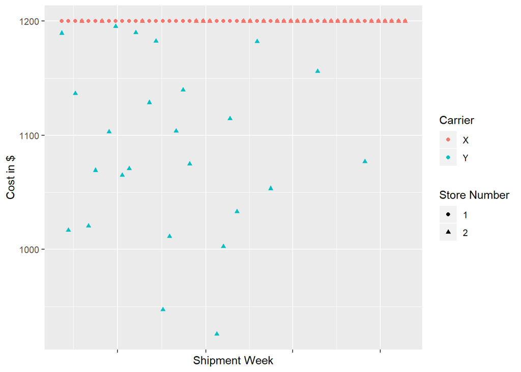

```r
x %>%
  ggplot(aes(x = `Shipment Date`,
             y = newcheaper)) +
  geom_point(aes(shape = factor(`Str Nbr`),
                 color = which.carrier)) +
  theme(axis.text.x=element_blank()) +
  xlab("Shipment Week") +
  ylab("Cost in $") +
  labs(shape = "Store Number", color = "Carrier")
```